# R Notebook

```r
library(tidyverse)
library(magrittr)
library(glue)
library(reshape2)
```

```r
library(rvest)
library(xml2)
```

# Cost of Living in Texas

First, I would like to see the cost of Living in Texas so I downloaded the data from the website. I then briefly overviewed the cost of living in texas across different domains:

```r
Texas <- read_html("https://www.bestplaces.net/cost_of_living/city/texas/austin")
cost <- html_nodes(Texas, "#mainContent_dgCostOfLiving td")
html_text(cost)
```

```
 [1] "  COST OF LIVING"   "Austin, Texas"      "United States"      "  Overall  "
 [5] "117"                "100"                "  Grocery  "        "89.1"
 [9] "100"                "  Health  "         "101"                "100"
[13] "  Housing  "        "161"                "100"                "  Utilities  "
[17] "91"                 "100"                "  Transportation  " "101"
[21] "100"                "  Miscellaneous  "  "99"                 "100"
```

Next, I turned the html file into a data frame for exploration:

```r
Cost <- html_nodes(Texas, css = "table")
Cost_of_living <- html_table(Cost, header = TRUE, fill = TRUE)[[2]]
Cost_of_living
```

| COST OF LIVING | Austin, Texas | United States |
| --- | --- | --- |
| Overall | 117.0 | 100 |
| Grocery | 89.1 | 100 |
| Health | 101.0 | 100 |
| Housing | 161.0 | 100 |
| Utilities | 91.0 | 100 |
| Transportation | 101.0 | 100 |
| Miscellaneous | 99.0 | 100 |

```r
write.csv(Cost_of_living, file = "Cost_of_living.csv")
```

For ease of exploration and graphing, I decided to turn it into long format:

```r
Cost_long <- melt(Cost_of_living, id.vars=c("COST OF LIVING"))
colnames(Cost_long)[1] <- "Living"
colnames(Cost_long)[3] <- "Cost"
Cost_long
```

| Living | variable | Cost |
| --- | --- | --- |
| Overall | Austin, Texas | 117.0 |
| Grocery | Austin, Texas | 89.1 |
| Health | Austin, Texas | 101.0 |
| Housing | Austin, Texas | 161.0 |
| Utilities | Austin, Texas | 91.0 |
| Transportation | Austin, Texas | 101.0 |
| Miscellaneous | Austin, Texas | 99.0 |
| Overall | United States | 100.0 |
| Grocery | United States | 100.0 |
| Health | United States | 100.0 |

[output cut: 4 more lines]

Looking at the data frame, I realized the cost values of United States are consistently the same across different domains so instead of graphing values of United States, I put them as a reference line.

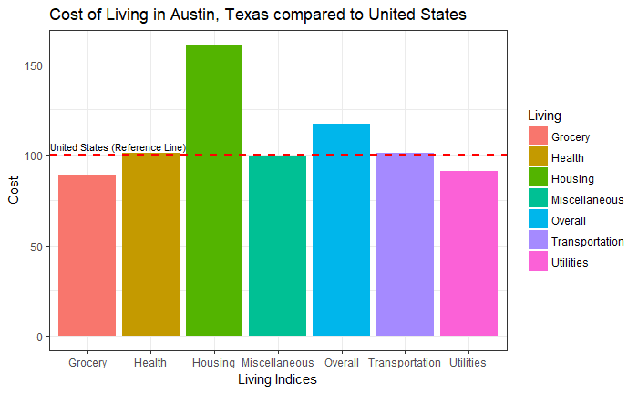

```r
Cost_long %>%
    filter(variable != "United States") %>%
    ggplot(aes(x=Living, y=Cost, fill = Living)) +
    geom_bar(stat = "identity") +
      geom_hline(yintercept = 100, colour = "red", linetype = "dashed", size = 1) +
      annotate("text",x = 1.5, y=105,size=3,label=c("United States (Reference Line)")) +
      theme_bw() +
      xlab("Living Indices") + ylab("Cost") +
      ggtitle("Cost of Living in Austin, Texas compared to United States")
```

# Education in Texas

Next, I explored the Education aspect of Texas, then turned them into dataframe:

```r
Texas_education <- read_html("https://www.bestplaces.net/education/city/texas/austin")
Education <- html_table(Texas_education, header = TRUE, fil = TRUE)[[2]]
Education
```

| EDUCATION | Austin, Texas | United States |
| --- | --- | --- |
| Expend. per Student | $12,118 | $12,383 |
| Educ. Expend. per Student | $9,484 | $10,574 |
| Instr. Expend. per Student | $5,522 | $6,428 |
| Pupil/Teacher Ratio | 14.5 | 16.8 |
| Students per Librarian | 650 | 538.1 |
| Students per Counselor | 484.4 | 403.2 |

```r
write.csv(Education, file = "Education.csv")
```

Looking at the dataframe, I realized that the education measurement units are not the same. The first 3 aspects are related to cost of Education, whereas the last 3 aspects are related to ratio between students and staff/teacher.

Thus, I divided the dataframe into 2 parts. The first part explored the cost of education:

```r
Education_Cost <- c("Expend. per Student", "Educ. Expend. per Student", "Instr. Expend. per Student")
Cost_Education <- Education[Education$EDUCATION %in% Education_Cost, ] %>%
    melt(id.vars = c("EDUCATION")) %>%
    mutate(value = value %>%
                    str_replace_all("\\D","") %>%
                    as.numeric())
Cost_Education
```

| EDUCATION | variable | value |
| --- | --- | --- |
| Expend. per Student | Austin, Texas | 12118 |
| Educ. Expend. per Student | Austin, Texas | 9484 |
| Instr. Expend. per Student | Austin, Texas | 5522 |
| Expend. per Student | United States | 12383 |
| Educ. Expend. per Student | United States | 10574 |
| Instr. Expend. per Student | United States | 6428 |

graph of cost of education:

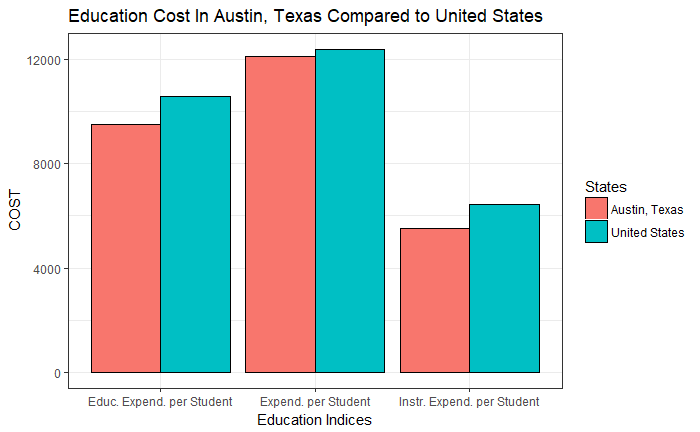

```r
ggplot(data=Cost_Education, aes(x=EDUCATION, y=value, fill=variable)) +
    geom_bar(colour="black", stat="identity",
             position=position_dodge(),
             size=.3) +
    scale_fill_hue(name="States") +
    xlab("Education Indices") + ylab("COST") +
    ggtitle("Education Cost In Austin, Texas Compared to United States") +
    theme_bw()
```

The second part explored the ratio between students and staff/teachers:

```r
Education_Ratio <- c("Pupil/Teacher Ratio", "Students per Librarian", "Students per Counselor")
Ratio_Education <- Education[Education$EDUCATION %in% Education_Ratio, ] %>%
    melt(id.vars = c("EDUCATION")) %>%
  mutate(value = value %>%
             as.numeric())
Ratio_Education
```

| EDUCATION | variable | value |
| --- | --- | --- |
| Pupil/Teacher Ratio | Austin, Texas | 14.5 |
| Students per Librarian | Austin, Texas | 650.0 |
| Students per Counselor | Austin, Texas | 484.4 |
| Pupil/Teacher Ratio | United States | 16.8 |
| Students per Librarian | United States | 538.1 |
| Students per Counselor | United States | 403.2 |

graph of ratio education:

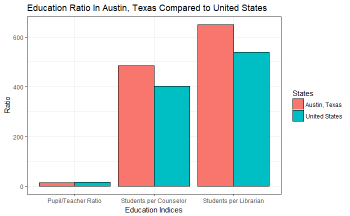

```r
ggplot(data=Ratio_Education, aes(x=EDUCATION, y=value, fill=variable)) +
    geom_bar(colour="black", stat="identity",
             position=position_dodge(),
             size=.3) +
    scale_fill_hue(name="States") +
    xlab("Education Indices") + ylab("Ratio") +
    ggtitle("Education Ratio In Austin, Texas Compared to United States") +
    theme_bw()
```